# second week: Introduction to R and Rstudio

Mobile Data

Arefe Abghari

2018-02-19 23:35:25

# تمرین سری دوم: تلفن همراه شناسی!

> با استفاده از داده های گوشی های همراه به سوالات زیر پاسخ دهید. برای رسم نمودار از پکیج ggplot2 استفاده کنید.

۱. کدام شرکت بیشترین تعداد گوشی را تولید کرده است؟ نمودار ستونی ۲۰ شرکت برتر بر حسب تعداد گوشی تولید کرده را رسم کنید.

#### پاسخ:

ابتدا گروه بندی را برحسب کمپانی انجام داده ام و سپس تعداد موبایل هایی که هر کمپانی تولید کرده است را به دست آورده ام و بر حسب این تعداد $arrange$ کرده ام. و سپس با تابع $slice$ ۲۰ کمپانی اول را جدا کرده ام. و با $geom_bar$ نمودار ستونی را ترسیم نموده ام .

```r
library(readr)
library(ggplot2)
library(dplyr)
mobile = read_csv("/Users/arefe/Downloads/mobile_data.csv")
#View(mobile)




mobile %>%
  group_by(company) %>%
  summarise(number=n())->stat1

df=data.frame(n=stat1$number ,c=stat1$company, stringsAsFactors = FALSE)
df%>%
  arrange(desc(n)) %>%
  slice(1:20)->stat
print(stat[1,2])
```

```
## # A tibble: 1 x 1
##   c
##   <chr>
## 1 Samsung
```

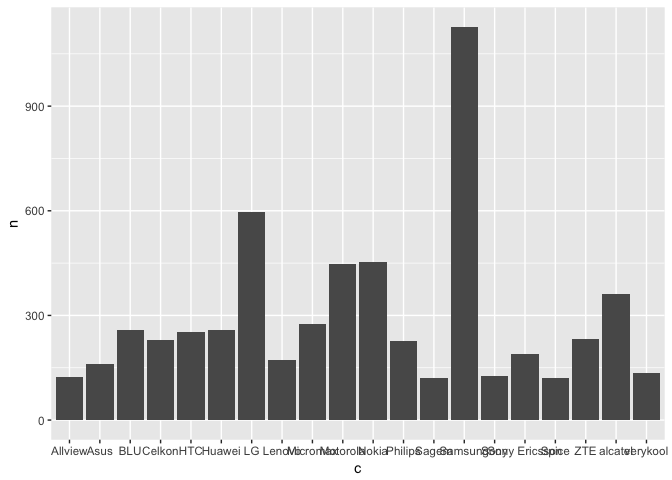

```r
p=ggplot(data=stat, aes(x= c, y=n))
p+geom_bar(stat="identity")
```

۲. نمودار زمانی طول عرض ضخامت و کیفیت دوربین گوشی ها را بکشید و به نمودار هر یک مدل خطی اضافه کنید.

#### پاسخ:

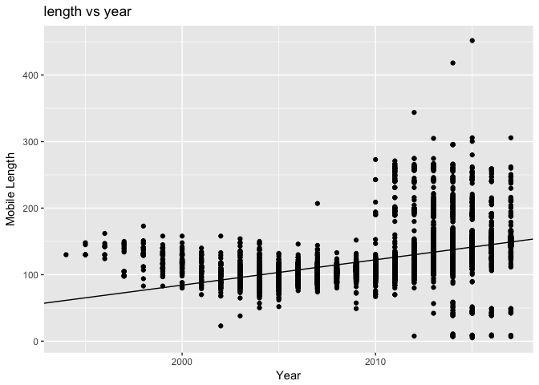

```r
### 2nd part


library(readr)
library(ggplot2)
library(dplyr)
mobile = read_csv("/Users/arefe/Downloads/mobile_data.csv")
mobile %>%
  group_by(year) %>%
  summarise(lngth=mean(dim_length , na.rm=T))->stat2

#plot(stat2$year, stat2$lngth,pch=16,type="l", xlab="year" , ylab="length" )#a title="Mobile Length vs Time")
p=ggplot(data=mobile , aes(x=year , y=dim_length))+geom_point()
p=p + xlab('Year') +ylab('Mobile Length') + ggtitle('length vs year')
coef=coef(lm(dim_length ~ year, data=mobile ))
p + geom_abline(intercept=coef[1] , slope=coef[2] )
```

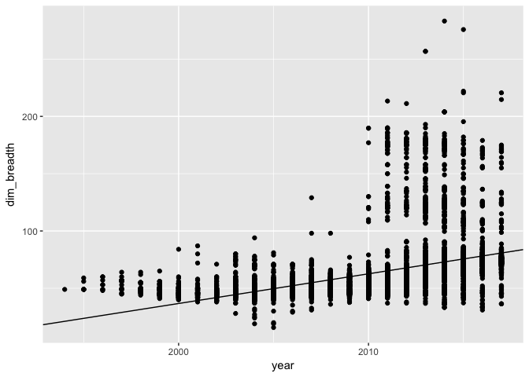

```r
mobile %>%
  group_by(year) %>%
  summarise(brdth=mean(dim_breadth , na.rm=T))->stat3

p=ggplot(data=mobile , aes(x=year, y=dim_breadth))+geom_point()
coef=coef(lm(dim_breadth ~ year, data=mobile ))
p + geom_abline(intercept=coef[1] , slope=coef[2] )
```

[figure not shown]

```r
mobile %>%
  group_by(year) %>%
  summarise(thkns=mean(dim_thickness , na.rm=T))->stat4

p=ggplot(data=mobile , aes(x=year , y=dim_thickness))+geom_point()
p=p + xlab('Year') +ylab('Mobile Thickness') + ggtitle('length vs year')
coef=coef(lm(dim_thickness ~ year, data=mobile ))
p + geom_abline(intercept=coef[1] , slope=coef[2] )
```

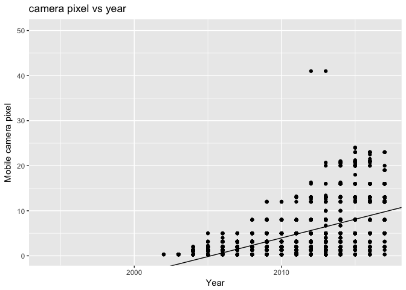

```r
#plot(stat4$year, stat4$thkns,pch=16,type="l", xlab="year" , ylab="thickness" ) #title="Mobile Breadth vs Time "


mobile %>%
  group_by(year) %>%
  summarise(cam=mean(cam_px , na.rm=T))->stat5

#plot(stat5$year, stat5$cam,pch=16,type="l", xlab="year" , ylab="Camera" ) #title="Mobile Breadth vs Time "

p=ggplot(data=mobile , aes(x=year , y=cam_px))+geom_point()
p=p + xlab('Year') +ylab('Mobile camera pixel') + ggtitle('camera pixel vs year')
coef=coef(lm(cam_px ~ year, data=mobile ))
p + geom_abline(intercept=coef[1] , slope=coef[2] )
```

۳. نمودار ستونی متوسط قیمت گوشی بر حسب تعداد سیم کارت و دسترسی به LTE را رسم نمایید.

#### پاسخ:

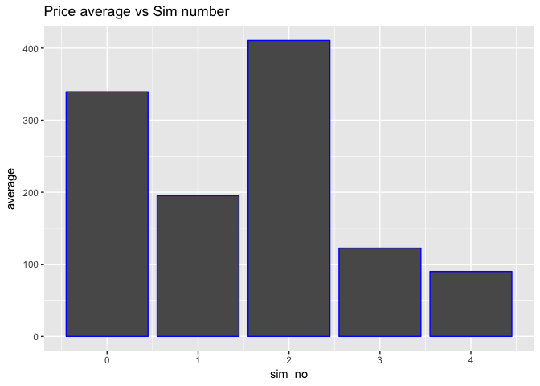

```r
library(readr)
library(ggplot2)
library(dplyr)
mobile = read_csv("/Users/arefe/Downloads/mobile_data.csv")
mobile %>%
  group_by(sim_no) %>%
  summarise(average=mean(price,na.rm=T))->stat1
p=ggplot(data=stat1, aes(x=sim_no , y=average))
p+geom_bar(stat="identity" , color='blue')+ggtitle("Price average vs Sim number")
```

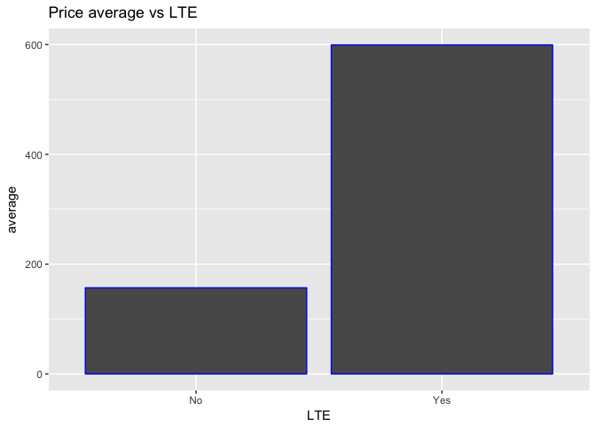

```r
mobile %>%
  group_by(LTE) %>%
  summarise(average=mean(price,na.rm=T))->stat2
p=ggplot(data=stat2, aes(x=LTE , y=average))
p+geom_bar(stat="identity" , color='blue')+ggtitle("Price average vs LTE")
```

***

۴. نمودار جعبه ایی ضحامت گوشی هایی که در سال ۲۰۱۷ معرفی شده اند را برحسب اینکه کمیت جک هدفون رسم نمایید

#### پاسخ:

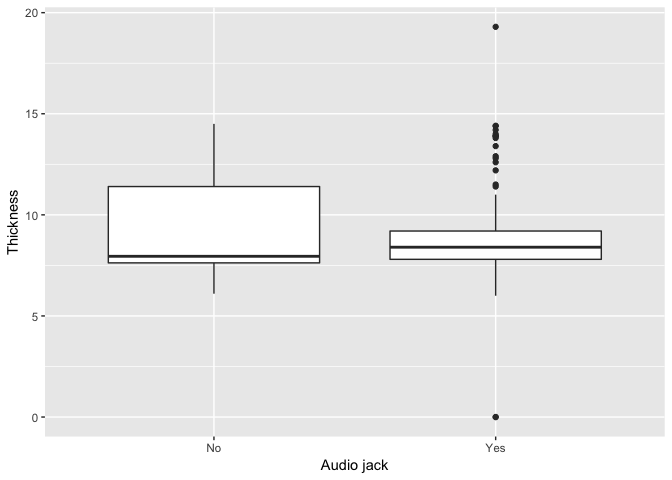

```r
library(readr)
library(ggplot2)
library(dplyr)
mobile = read_csv("/Users/arefe/Downloads/mobile_data.csv")
seventeen = mobile[which(mobile$year==2017),]
plot = ggplot(seventeen, aes(audio_jack,dim_thickness))
plot + geom_boxplot() + xlab("Audio jack") + ylab("Thickness")
```

***

۵. مفهوم ppi را در گوشی های موبایل محاسبه و هیستوگرام آن را رسم نمایید. همچنین نمودار سالانه متوسط این کمیت را بکشید. کدام گوشی بیشترین ppi را دارد؟

#### پاسخ:

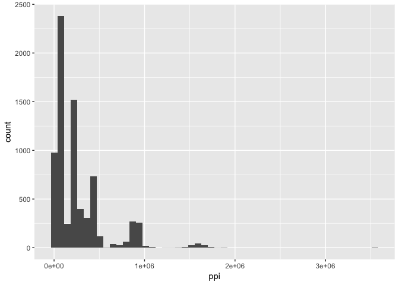

```r
## 6

library(readr)
library(ggplot2)
library(dplyr)
mobile = read_csv("/Users/arefe/Downloads/mobile_data.csv")
df=data.frame( device=mobile$device,year=mobile$year, size=mobile$display_size, npx=sqrt(mobile$px_row **2+ mobile$px_col**2) , ppi= (mobile$px_row **2+ mobile$px_col**2)/mobile$display_size , stringsAsFactors = FALSE)
#View(df)
df=df[complete.cases(df), ]

p=ggplot(data=df , aes(x=ppi))
p+geom_histogram(bins=50)
```

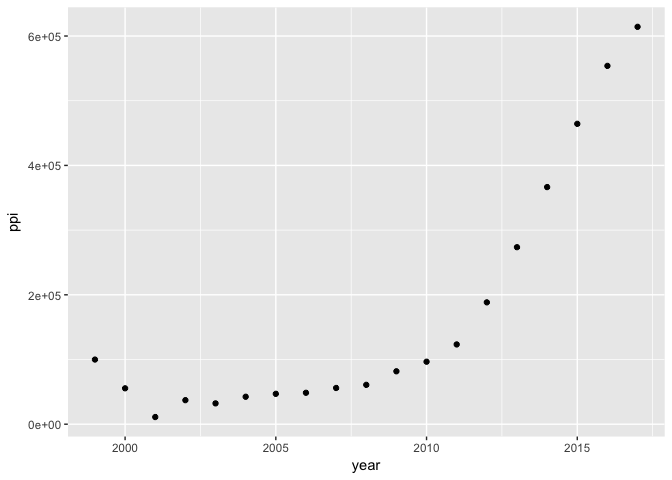

```r
df %>%
  group_by(year) %>%
  summarise( ppi=mean(ppi))->stat
p=ggplot(data=stat , aes(x=year, y=ppi))
p+geom_point()
```

```r
m=max(df$ppi)
print(df[df$ppi==m,1])
```

```
## [1] "Xperia XZ Premium"
```

۶. در گذشته به بعضی از مدل های گوشی نوکیا **گوشکوب** گفته می شد. سعی کنید برای این مفهوم کمیتی مناسب تعریف کنید . ده گوشکوب برتر را پیدا کرده و نمودار گوشکوبیت آن را رسم نمایید.

#### پاسخ:

مفهوم گوشکوب را به این صورت تعریف کرده ام که حاصل تقسیم کلفتی بر طول را به دست آورده ام و ۱۰ گوشی که از این جهت بیشترین مقدار است را به دست آورده ام.

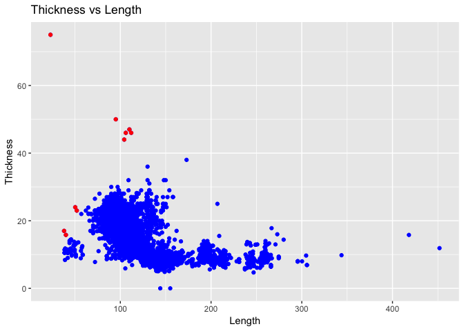

```r
library(readr)
library(ggplot2)
library(dplyr)
mobile = read_csv("/Users/arefe/Downloads/mobile_data.csv")
df=data.frame(com=mobile$company, device=mobile$device ,year=mobile$year, thkns=mobile$dim_thickness , lngth=mobile$dim_length , gooshkoob=100*mobile$dim_thickness/mobile$dim_length)
#View(df)
df=df[complete.cases(df), ]

m=mean(df$gooshkoob,na.rm=T)
df %>%
 # filter(year<2002) %>%
  arrange(desc(gooshkoob)) %>%
  slice (1:10)->df1

p<- ggplot()+geom_point(data=df , aes(x=lngth, y=thkns) , color="blue")


p+geom_point(data=df1 , aes(x=lngth, y=thkns) , color="red")+ggtitle("Thickness vs Length") +xlab("Length") +ylab("Thickness")
```

۷. آیا تلفن همراهی وجود دارد که در آب غرق نشود؟ اگر جواب بله هست تمام گوشی های که این خاصیت را دارند بیابید. با کشیدن یک نمودار به این سوال پاسخ دهید.

#### پاسخ:

گوشی هایی که چگالیشان از آب کمتر باشد در آب غرق نمیشوند نمودار جرم بر حسب حجم را رسم نموده ام . آن هایی که پایین خط $y=x$ قرار دارند چگالیشان از آب کمتر است.

```r
## 7
library(readr)
library(ggplot2)
library(dplyr)
mobile = read_csv("/Users/arefe/Downloads/mobile_data.csv")
df=data.frame(com=mobile$company, device=mobile$device, mass=mobile$weight , thkns=mobile$dim_thickness , lngth=mobile$dim_length , brdth= mobile$dim_breadth , vol=mobile$dim_thickness * mobile$dim_breadth * mobile$dim_length/1000,density=1000* mobile$weight/(mobile$dim_thickness * mobile$dim_breadth * mobile$dim_length))
#View(df)
df=df[complete.cases(df), ]

df<-df[df$density <1  ,]

print (df$device)
```

```
##    [1] 2040                   OT-308                 OT-292
##    [4] OT-228                 OT-665                 OT-361
##    [7] OT-223                 OT-217                 OT-213
##   [10] OT-209                 OT-117                 OT-113
##   [13] OT-112                 OT-109                 OT-105
##   [16] OT-108                 OT-216                 OT-206
##   [19] OT-208                 OT-301                 OT-300
##   [22] OT-305                 OT-505                 OT-508A
##   [25] OT-565                 OT-106                 OT-660
##   [28] OT-383                 OT-203                 OT-103
##   [31] ELLE GlamPhone         OT-363                 Roadsign
##   [34] OT-102                 Mandarina Duck Moon    Mandarina Duck
##   [37] OT-V670                OT-V607A               OT-V270
##   [40] OT-S107                OT-C717                OT-C700A
##   [43] OT-E227                OT-E225                OT-E221
```

[output cut: 324 more lines]

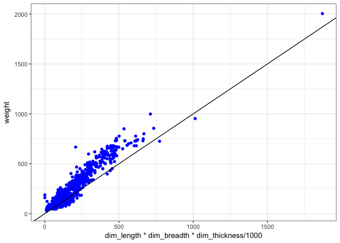

```r
#View(df)

p=ggplot(data=mobile, aes( x=dim_length* dim_breadth * dim_thickness/1000 ,  y= weight ,))  + geom_point(color='blue')+  theme_bw()
p+  geom_abline(data=mobile,aes(slope=1,intercept=0))
```

۸. نمودار پراکنش حجم ذخیره سازی باطری و وزن را رسم نمایید. میزان همبستگی بین این دو کمیت را محاسبه کنید.

#### پاسخ:

[figure not shown]

```r
library(readr)
library(ggplot2)
library(dplyr)
mobile = read_csv("/Users/arefe/Downloads/mobile_data.csv")
# p=ggplot(data=mobile, aes(x=battery_mah , y= wieght ))
# p+geom_point()
y=mobile$weight
x=mobile$battery_mah
plot (x=mobile$battery_mah,y=mobile$weight,pch=1, main="Weight vs Battery size" , xlab="Weigth" , ylab="Battery size")
```

```r
cor(x,y, use="complete.obs")
```

```
## [1] 0.8086273
```

۹. قیمت پرچمداران یک برند خاص مثلا سامسونگ را بیابید و نمودار قیمت زمان و نام مدل را رسم نمایید.

```r
library(readr)
library(ggplot2)
library(dplyr)
library(devtools)
mobile = read_csv("/Users/arefe/Downloads/mobile_data.csv")
mobile %>%
  group_by(year) %>%
  filter(company=="Samsung") %>%

  slice(which.max(price)) %>%
  select(device=device, price=price)->stats
stats=stats[complete.cases(stats), ]
print(stats$device)
```

```
##  [1] "E630"                     "D820"
##  [3] "P930"                     "Serenata"
##  [5] "S9402 Ego"                "B7620 Giorgio Armani"
##  [7] "I6500U Galaxy"            "P7500 Galaxy Tab 10.1 3G"
##  [9] "Ativ Tab P8510"           "Galaxy Round G910S"
## [11] "Galaxy Note Pro 12.2 LTE" "Galaxy View"
## [13] "Galaxy Note7"             "Galaxy Note8"
```

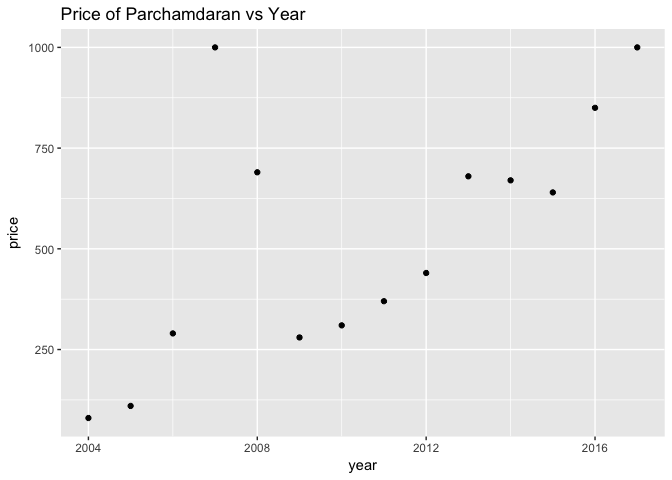

```r
p=ggplot(data=stats, aes(x=year , y=price))
p+geom_point()+ggtitle("Price of Parchamdaran vs Year")
```

***

۱۰. سه نمودار جالب رسم کنید و توضیح دهید چرا از نظر شما جالب است؟

#### پاسخ:

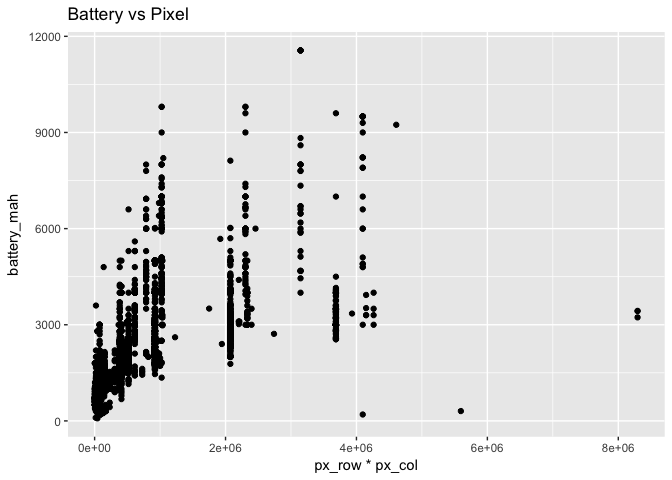

```r
library(readr)
library(ggplot2)
library(dplyr)
library(devtools)
mobile = read_csv("/Users/arefe/Downloads/mobile_data.csv")
x=mobile$px_row*mobile$px_col
y=mobile$battery_mah
p=ggplot(data=mobile, aes(x=px_row*px_col , y=battery_mah))


p + geom_point() +ggtitle("Battery vs Pixel")
```

```r
cor (x,y, use="complete.obs")
```

```
## [1] 0.7009805
```

نمودار جالب دوم نمودار تعداد موبایل های تولیدی ۵ شرکت معروف بر حسب زمان است

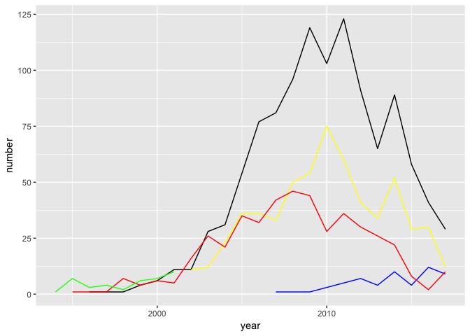

```r
library(readr)
library(ggplot2)
library(dplyr)
library(devtools)
mobile = read_csv("/Users/arefe/Downloads/mobile_data.csv")
mobile %>%
  filter(company=="Samsung") %>%
  group_by( year ) %>%
  summarise(number=n())->num1
mobile %>%
  filter(company=="Apple") %>%
  group_by( year ) %>%
  summarise(number=n())->num2
mobile %>%
  filter(company=="LG") %>%
  group_by( year ) %>%
    summarise(number=n())->num3

mobile %>%
  filter(company=="Nokia") %>%
  group_by( year ) %>%
  summarise(number=n())->num4
num4=num4[complete.cases(num4), ]
mobile %>%
  filter(company=="Ericsson") %>%
  group_by( year ) %>%
  summarise(number=n())->num5

num5=num5[complete.cases(num5), ]

  p=ggplot()+geom_line(data=num1 , aes(x=year, y=number ), color="black")+geom_line(data=num2 , aes(x=year, y=number ), color="blue")+geom_line(data=num3 , aes(x=year, y=number ), color="yellow")
 p=p +geom_line(data=num4 , aes(x=year, y=number ), color="red")
 p+geom_line(data=num5 , aes(x=year, y=number ), color="green")
```

.نمودار جالب سوم قدرت دوربین بر حسب حجم موبایل است

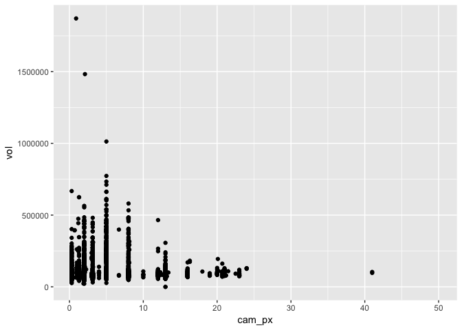

```r
library(readr)
library(ggplot2)
library(dplyr)
library(devtools)
mobile = read_csv("/Users/arefe/Downloads/mobile_data.csv")
 mobile%>%
  select (cam_px,dim_breadth , dim_length ,dim_thickness) %>%
   mutate(vol=dim_breadth*dim_length *dim_thickness)->volume
 p=ggplot(data=volume , aes(x=cam_px , y=vol))
 p+geom_point()
```